# FOR/STT 875, Exercise 8

## Learning objectives

- Work with messy data
- Import data from an external spreadsheet
- Practice using functions in `tidyr` and `ggplot2`

## Overview

Modify this R Markdown file by filling in the code needed to answer the questions.

In this exercise we’ll experience a small amount of the pain (or pleasure, depending on your perspective) of working with realistic data sets.

## Submission instructions

Upload your exercise_8.Rmd and exercise_8.html files to the Exercise 8 D2L dropbox.

## Grading

You will receive full credit if your R Markdown document: 1) compiles without error; and 2) correctly completes the `# TODO:` code chunks. Also, please, fill in the feedback questions at the end of the exercise.

## Getting the “raw” data from Gapminder

Go to http://www.gapminder.org/data/. You should see a search box in a popup window in the middle of the screen. In this box, type “life expectancy”. Hover over the first result, and you should see a description on the right with the title “Life expectancy (years)”.

Click on the first result, and you should see the data set pop up in a display, with multiple options for download as a .csv file, a .xlsx file, as well as different viewing options. Although there is an option to save the file as a .csv file directly, download the .xlsx file so we can practice converting an Excel spreadsheet into a csv file. Notice the first column has a list of countries, and the subsequent columns have life expectancies for years from 1800 predicted all the way to 2100. How are NA values included in the data set?

Although it’s possible to read Excel spreadsheets directly into R, we’ll first save the spreadsheet as a CSV file. Save it in the working directory of your R session. (If you don’t know the working directory, type `getwd()` in the console window. Ideally you’ve created a new R project in a directory of your choice, and this will be the working directory.) Excel will probably remind you that it can only save the active sheet, and will also give various other warnings about saving as a CSV file. Choose a simple name such as `LifeExp.csv` since you’ll have to use this name as an argument to the `read.csv` function soon.

## Getting the data into R and doing some clean up

Use `read.csv` to read the data into an object called `gapminder1`. Make sure to use `na.strings` to specify how missing data are indicated in the CSV file.

```r
#TODO 8.1: Read in LifeExp.csv and check that it was read in correctly
gapminder1 <- read.csv("LifeExp.csv", header = TRUE, na.strings = "")
dim(gapminder1)
```

```
## [1] 187 302
```

Investigate the data using `str`, `head`, `names`, etc., to make sure it was read in correctly. (Hint: it should have 187 rows and 302 columns.) You don’t need to submit code for this, just convince yourself it was read in correctly. Because names in R cannot start with a number, the columns after the first column have an `X` prepended, e.g., `X1804` and `X2001`. We’ll address this later on.

Note that some spreadsheet applications do weird things when exporting data into csvs, which may cause your data set to show up as having 999 rows instead of 187. If this is the case, then use the code `gapminder1 <- gapminder1[1:187, ]` to only work with the 187 rows that comprise the data set.

## Computing some summary statistics

Use `apply` to compute the **mean, median, minimum, and maximum** life expectancy for each year. You’ll need to exclude the first column, and also will need to tell R how to handle missing values.

```r
#TODO 8.2: calculate mean, median, minimum, and maximum life expetancy for each year here
apply(gapminder1[,2:ncol(gapminder1)], MARGIN = 2, mean, na.rm = TRUE)
```

```
##    X1800    X1801    X1802    X1803    X1804    X1805    X1806    X1807
## 31.50272 31.46196 31.47880 31.38315 31.45924 31.58641 31.64457 31.59837
##    X1808    X1809    X1810    X1811    X1812    X1813    X1814    X1815
## 31.38315 31.31033 31.54185 31.49837 31.48750 31.48261 31.53533 31.67880
##    X1816    X1817    X1818    X1819    X1820    X1821    X1822    X1823
## 31.65652 31.75924 31.59946 31.50489 31.58424 31.64946 31.76087 31.81359
##    X1824    X1825    X1826    X1827    X1828    X1829    X1830    X1831
## 31.74620 31.69891 31.62337 31.66304 31.60163 31.58370 31.67065 31.63261
##    X1832    X1833    X1834    X1835    X1836    X1837    X1838    X1839
## 31.59348 31.58913 31.57500 31.70870 31.67228 31.60598 31.67174 31.66196
##    X1840    X1841    X1842    X1843    X1844    X1845    X1846    X1847
## 31.75272 31.79891 31.77337 31.75761 31.82120 31.87500 31.56848 31.64728
##    X1848    X1849    X1850    X1851    X1852    X1853    X1854    X1855
## 31.64457 31.48043 31.66630 31.81522 31.83098 31.82880 31.70272 31.73967
##    X1856    X1857    X1858    X1859    X1860    X1861    X1862    X1863
## 31.75380 31.75652 31.76141 31.72880 31.80761 31.77337 31.70380 31.75978
##    X1864    X1865    X1866    X1867    X1868    X1869    X1870    X1871
## 31.68804 31.64511 31.51902 31.52935 31.24951 31.57500 31.81848 31.76033
##    X1872    X1873    X1874    X1875    X1876    X1877    X1878    X1879
## 31.85326 31.94620 32.01467 31.89734 32.10761 32.19565 32.20978 32.33696
##    X1880    X1881    X1882    X1883    X1884    X1885    X1886    X1887
## 32.34891 32.41250 32.36685 32.53098 32.68696 32.75978 32.82826 32.89185
##    X1888    X1889    X1890    X1891    X1892    X1893    X1894    X1895
## 32.93533 32.92935 32.70772 32.92337 32.93967 33.01348 33.25489 33.33804
##    X1896    X1897    X1898    X1899    X1900    X1901    X1902    X1903
## 33.44130 33.52283 33.56793 33.54565 33.61087 33.80435 33.90054 33.94511
##    X1904    X1905    X1906    X1907    X1908    X1909    X1910    X1911
## 33.99125 34.04022 34.17772 34.30054 34.41902 34.68315 34.82772 34.95707
##    X1912    X1913    X1914    X1915    X1916    X1917    X1918    X1919
## 35.19076 35.22011 34.96033 34.59027 34.70924 34.54674 22.94962 34.69837
##    X1920    X1921    X1922    X1923    X1924    X1925    X1926    X1927
## 34.95978 35.44239 35.76793 36.51902 36.80543 36.99022 37.37826 37.54076
##    X1928    X1929    X1930    X1931    X1932    X1933    X1934    X1935
## 37.85815 37.87609 38.37065 38.34728 38.33886 38.12560 39.67174 40.06576
##    X1936    X1937    X1938    X1939    X1940    X1941    X1942    X1943
## 40.56467 40.87663 41.39946 41.87337 41.82228 40.33913 40.14239 39.91413
##    X1944    X1945    X1946    X1947    X1948    X1949    X1950    X1951
## 39.71685 41.55326 45.13696 45.67391 47.83315 48.96304 50.08261 50.29076
##    X1952    X1953    X1954    X1955    X1956    X1957    X1958    X1959
## 50.90054 51.54402 52.22065 52.79565 53.33043 53.79891 54.41576 54.86087
```

[output cut: 21 more lines]

```
## 76.93152 77.09239 77.24565 77.39511 77.55272 77.69891 77.85000 77.99728
##    X2048    X2049    X2050    X2051    X2052    X2053    X2054    X2055
## 78.14674 78.28696 78.43533 78.57663 78.72011 78.86576 79.00435 79.14293
##    X2056    X2057    X2058    X2059    X2060    X2061    X2062    X2063
## 79.28098 79.41793 79.55978 79.69457 79.82826 79.96304 80.09837 80.23533
##    X2064    X2065    X2066    X2067    X2068    X2069    X2070    X2071
## 80.36359 80.49620 80.62500 80.75924 80.88913 81.01359 81.15000 81.26902
##    X2072    X2073    X2074    X2075    X2076    X2077    X2078    X2079
## 81.40489 81.53261 81.66141 81.78478 81.91304 82.04022 82.16522 82.28478
##    X2080    X2081    X2082    X2083    X2084    X2085    X2086    X2087
## 82.41196 82.53424 82.65707 82.78424 82.90543 83.03152 83.14783 83.27228
##    X2088    X2089    X2090    X2091    X2092    X2093    X2094    X2095
## 83.39239 83.51630 83.63261 83.75815 83.87663 83.99620 84.11902 84.23696
##    X2096    X2097    X2098    X2099    X2100
## 84.35815 84.47880 84.59348 84.71087 84.82989
```

```r
apply(gapminder1[,2:ncol(gapminder1)], MARGIN = 2, median, na.rm = TRUE)
```

```
## X1800 X1801 X1802 X1803 X1804 X1805 X1806 X1807 X1808 X1809 X1810 X1811 X1812
## 31.75 31.65 31.55 31.50 31.55 31.65 31.75 31.75 31.55 31.50 31.75 31.65 31.70
## X1813 X1814 X1815 X1816 X1817 X1818 X1819 X1820 X1821 X1822 X1823 X1824 X1825
## 31.65 31.65 31.75 31.65 31.75 31.75 31.75 31.75 31.65 31.80 31.80 31.80 31.80
## X1826 X1827 X1828 X1829 X1830 X1831 X1832 X1833 X1834 X1835 X1836 X1837 X1838
## 31.75 31.75 31.75 31.75 31.85 31.80 31.75 31.80 31.80 31.80 31.65 31.80 31.85
## X1839 X1840 X1841 X1842 X1843 X1844 X1845 X1846 X1847 X1848 X1849 X1850 X1851
## 31.80 31.90 31.85 31.85 31.80 31.85 31.85 31.75 31.85 31.85 31.80 31.80 31.80
## X1852 X1853 X1854 X1855 X1856 X1857 X1858 X1859 X1860 X1861 X1862 X1863 X1864
## 31.85 31.85 31.80 31.80 31.75 31.80 31.85 31.70 31.75 31.75 31.75 31.80 31.70
## X1865 X1866 X1867 X1868 X1869 X1870 X1871 X1872 X1873 X1874 X1875 X1876 X1877
## 31.70 31.65 31.70 31.55 31.55 31.75 31.65 31.70 31.70 31.80 31.75 31.80 31.85
## X1878 X1879 X1880 X1881 X1882 X1883 X1884 X1885 X1886 X1887 X1888 X1889 X1890
## 31.90 31.95 32.00 32.05 32.00 32.00 32.05 32.10 32.15 32.10 32.20 32.15 32.15
## X1891 X1892 X1893 X1894 X1895 X1896 X1897 X1898 X1899 X1900 X1901 X1902 X1903
## 32.20 32.20 32.20 32.35 32.30 32.35 32.40 32.45 32.50 32.55 32.65 32.65 32.75
## X1904 X1905 X1906 X1907 X1908 X1909 X1910 X1911 X1912 X1913 X1914 X1915 X1916
## 32.80 32.75 32.65 32.75 32.90 32.85 32.90 33.05 33.15 32.95 32.90 33.00 33.00
## X1917 X1918 X1919 X1920 X1921 X1922 X1923 X1924 X1925 X1926 X1927 X1928 X1929
## 32.90 22.00 33.10 32.90 33.05 33.55 33.70 33.90 34.05 34.25 34.35 34.40 34.50
## X1930 X1931 X1932 X1933 X1934 X1935 X1936 X1937 X1938 X1939 X1940 X1941 X1942
## 34.65 34.50 34.60 34.70 35.75 36.35 36.75 36.80 37.25 38.10 38.40 36.70 36.60
## X1943 X1944 X1945 X1946 X1947 X1948 X1949 X1950 X1951 X1952 X1953 X1954 X1955
## 37.15 36.45 38.90 44.50 43.40 47.35 48.75 50.00 50.25 50.70 51.30 52.05 52.65
## X1956 X1957 X1958 X1959 X1960 X1961 X1962 X1963 X1964 X1965 X1966 X1967 X1968
## 53.80 54.45 55.00 55.45 55.90 56.35 56.80 57.45 58.15 58.90 59.95 60.90 61.40
## X1969 X1970 X1971 X1972 X1973 X1974 X1975 X1976 X1977 X1978 X1979 X1980 X1981
## 61.70 62.30 63.00 63.40 63.50 63.90 64.50 64.60 65.20 65.50 66.20 66.50 66.70
## X1982 X1983 X1984 X1985 X1986 X1987 X1988 X1989 X1990 X1991 X1992 X1993 X1994
## 66.80 67.40 67.80 68.10 68.60 68.90 68.90 69.60 69.50 69.70 69.40 69.20 69.50
## X1995 X1996 X1997 X1998 X1999 X2000 X2001 X2002 X2003 X2004 X2005 X2006 X2007
## 69.40 70.10 70.40 70.60 70.70 71.10 71.10 71.30 72.00 71.90 72.20 72.60 72.60
## X2008 X2009 X2010 X2011 X2012 X2013 X2014 X2015 X2016 X2017 X2018 X2019 X2020
## 72.80 72.90 73.30 73.40 73.20 73.10 73.10 73.30 73.70 74.00 74.15 74.20 74.35
## X2021 X2022 X2023 X2024 X2025 X2026 X2027 X2028 X2029 X2030 X2031 X2032 X2033
## 74.50 74.65 74.95 75.10 75.25 75.40 75.50 75.70 75.80 75.95 76.10 76.30 76.45
## X2034 X2035 X2036 X2037 X2038 X2039 X2040 X2041 X2042 X2043 X2044 X2045 X2046
## 76.65 76.75 76.90 77.05 77.20 77.30 77.40 77.55 77.70 77.85 77.95 78.15 78.30
## X2047 X2048 X2049 X2050 X2051 X2052 X2053 X2054 X2055 X2056 X2057 X2058 X2059
## 78.45 78.60 78.75 78.90 79.05 79.25 79.35 79.55 79.70 79.85 80.00 80.10 80.25
## X2060 X2061 X2062 X2063 X2064 X2065 X2066 X2067 X2068 X2069 X2070 X2071 X2072
## 80.40 80.55 80.70 80.85 81.00 81.15 81.25 81.40 81.55 81.65 81.80 81.95 82.05
## X2073 X2074 X2075 X2076 X2077 X2078 X2079 X2080 X2081 X2082 X2083 X2084 X2085
## 82.20 82.30 82.50 82.60 82.70 82.80 82.95 83.05 83.15 83.25 83.35 83.45 83.55
## X2086 X2087 X2088 X2089 X2090 X2091 X2092 X2093 X2094 X2095 X2096 X2097 X2098
## 83.70 83.80 83.90 84.00 84.10 84.20 84.35 84.45 84.55 84.65 84.75 84.85 85.00
## X2099 X2100
## 85.15 85.25
```

```r
apply(gapminder1[,2:ncol(gapminder1)], MARGIN = 2, min, na.rm = TRUE)
```

```
## X1800 X1801 X1802 X1803 X1804 X1805 X1806 X1807 X1808 X1809 X1810 X1811 X1812
## 23.40 23.40 23.40 19.60 23.40 23.40 23.40 23.40 12.50 13.40 23.40 23.40 23.00
## X1813 X1814 X1815 X1816 X1817 X1818 X1819 X1820 X1821 X1822 X1823 X1824 X1825
## 23.40 23.40 23.40 23.40 23.40  5.50  1.50  6.50 23.40 23.40 23.40 23.40 23.40
## X1826 X1827 X1828 X1829 X1830 X1831 X1832 X1833 X1834 X1835 X1836 X1837 X1838
## 23.40 23.40 23.40 23.40 23.40 23.40 23.00 20.40 23.40 23.40 23.40 23.40 23.40
## X1839 X1840 X1841 X1842 X1843 X1844 X1845 X1846 X1847 X1848 X1849 X1850 X1851
## 23.40 23.40 23.00 22.40 23.40 15.00 23.40 18.30 23.40 14.90 14.10 14.00 22.00
## X1852 X1853 X1854 X1855 X1856 X1857 X1858 X1859 X1860 X1861 X1862 X1863 X1864
## 23.40 23.40  7.50 23.40 17.60 23.40 23.40 23.40 19.80 22.00 22.70 23.40 23.20
## X1865 X1866 X1867 X1868 X1869 X1870 X1871 X1872 X1873 X1874 X1875 X1876 X1877
## 22.30 21.00  4.00  8.11 15.00 19.90 20.00 20.00 20.10 20.30  1.01 20.00 19.00
## X1878 X1879 X1880 X1881 X1882 X1883 X1884 X1885 X1886 X1887 X1888 X1889 X1890
## 20.00 21.20 21.40 21.60 17.70 22.00 22.20 22.40 22.60 22.80 17.00  5.00  4.00
## X1891 X1892 X1893 X1894 X1895 X1896 X1897 X1898 X1899 X1900 X1901 X1902 X1903
##  8.00 14.00  8.08 21.80 21.60 19.60 18.60 19.90 19.10 18.40 21.20 12.90 20.30
## X1904 X1905 X1906 X1907 X1908 X1909 X1910 X1911 X1912 X1913 X1914 X1915 X1916
##  5.19 10.40 20.30 18.10 21.20 21.40 21.50 21.70 21.80 22.00 22.10  7.21 19.60
## X1917 X1918 X1919 X1920 X1921 X1922 X1923 X1924 X1925 X1926 X1927 X1928 X1929
## 20.10  1.10 11.80 15.20 11.90 13.90 23.40 23.60 23.60 23.60 23.60 23.60 23.60
## X1930 X1931 X1932 X1933 X1934 X1935 X1936 X1937 X1938 X1939 X1940 X1941 X1942
## 23.70 16.30  8.15  4.07 23.70 23.70 23.00 23.70 23.70 23.70 23.70 12.00 14.90
## X1943 X1944 X1945 X1946 X1947 X1948 X1949 X1950 X1951 X1952 X1953 X1954 X1955
## 13.90 15.40 15.90 22.30 11.10 23.70 23.80 23.80 24.20 25.20 26.20 27.10 28.10
## X1956 X1957 X1958 X1959 X1960 X1961 X1962 X1963 X1964 X1965 X1966 X1967 X1968
## 29.10 30.10 31.00 32.00 31.60 33.90 34.50 34.90 35.30 35.80 36.50 37.20 38.00
## X1969 X1970 X1971 X1972 X1973 X1974 X1975 X1976 X1977 X1978 X1979 X1980 X1981
## 36.90 39.70 39.90 18.50 40.50 38.90 24.90 24.80 24.60 24.30 24.10 43.40 43.20
## X1982 X1983 X1984 X1985 X1986 X1987 X1988 X1989 X1990 X1991 X1992 X1993 X1994
## 43.70 41.40 40.50 42.40 43.40 44.80 45.40 46.00 46.60 46.90 46.50 46.10  9.64
## X1995 X1996 X1997 X1998 X1999 X2000 X2001 X2002 X2003 X2004 X2005 X2006 X2007
## 44.30 43.90 43.60 44.30 43.40 44.30 44.30 44.40 44.50 43.90 43.60 43.90 44.20
## X2008 X2009 X2010 X2011 X2012 X2013 X2014 X2015 X2016 X2017 X2018 X2019 X2020
## 44.50 44.90 32.50 48.00 48.90 48.50 48.70 50.50 51.70 51.90 52.40 52.90 53.30
## X2021 X2022 X2023 X2024 X2025 X2026 X2027 X2028 X2029 X2030 X2031 X2032 X2033
## 53.60 53.90 54.20 54.50 54.80 55.10 55.40 55.70 56.00 56.30 56.60 56.90 57.20
## X2034 X2035 X2036 X2037 X2038 X2039 X2040 X2041 X2042 X2043 X2044 X2045 X2046
## 57.40 57.70 58.00 58.30 58.50 58.80 59.00 59.30 59.50 59.70 60.00 60.20 60.40
## X2047 X2048 X2049 X2050 X2051 X2052 X2053 X2054 X2055 X2056 X2057 X2058 X2059
## 60.60 60.80 61.00 61.20 61.40 61.60 61.80 62.00 62.20 62.30 62.50 62.70 62.90
## X2060 X2061 X2062 X2063 X2064 X2065 X2066 X2067 X2068 X2069 X2070 X2071 X2072
## 63.00 63.20 63.40 63.50 63.70 63.80 64.00 64.10 64.30 64.40 64.50 64.70 64.80
## X2073 X2074 X2075 X2076 X2077 X2078 X2079 X2080 X2081 X2082 X2083 X2084 X2085
## 64.90 65.10 65.20 65.30 65.50 65.60 65.70 65.80 66.00 66.10 66.20 66.30 66.50
## X2086 X2087 X2088 X2089 X2090 X2091 X2092 X2093 X2094 X2095 X2096 X2097 X2098
## 66.60 66.70 66.80 66.90 67.00 67.10 67.30 67.40 67.50 67.60 67.70 67.80 67.90
## X2099 X2100
## 68.00 68.10
```

```r
apply(gapminder1[,2:ncol(gapminder1)], MARGIN = 2, max, na.rm = TRUE)
```

```
## X1800 X1801 X1802 X1803 X1804 X1805 X1806 X1807 X1808 X1809 X1810 X1811 X1812
##  42.9  40.3  44.4  44.8  42.8  44.3  45.8  43.6  43.5  41.7  43.1  40.1  43.5
## X1813 X1814 X1815 X1816 X1817 X1818 X1819 X1820 X1821 X1822 X1823 X1824 X1825
##  43.0  41.7  45.6  46.3  48.9  46.8  45.8  47.0  44.7  48.4  48.8  47.6  49.2
## X1826 X1827 X1828 X1829 X1830 X1831 X1832 X1833 X1834 X1835 X1836 X1837 X1838
##  47.6  48.4  46.2  46.3  45.8  45.7  47.6  44.9  42.0  47.1  46.5  44.2  43.1
## X1839 X1840 X1841 X1842 X1843 X1844 X1845 X1846 X1847 X1848 X1849 X1850 X1851
##  43.0  45.6  49.5  48.4  48.4  49.7  50.1  48.0  44.8  45.1  48.0  49.5  49.7
## X1852 X1853 X1854 X1855 X1856 X1857 X1858 X1859 X1860 X1861 X1862 X1863 X1864
##  48.5  48.6  51.6  50.4  50.4  50.2  51.6  49.9  50.0  47.6  47.6  47.6  48.8
## X1865 X1866 X1867 X1868 X1869 X1870 X1871 X1872 X1873 X1874 X1875 X1876 X1877
##  50.4  49.9  47.9  47.2  49.3  50.9  49.7  50.1  49.7  47.8  47.6  46.8  49.8
## X1878 X1879 X1880 X1881 X1882 X1883 X1884 X1885 X1886 X1887 X1888 X1889 X1890
##  51.8  53.2  51.9  50.5  48.6  49.6  50.8  51.0  51.7  51.7  52.3  52.5  50.5
## X1891 X1892 X1893 X1894 X1895 X1896 X1897 X1898 X1899 X1900 X1901 X1902 X1903
##  51.1  52.7  52.6  52.1  54.1  53.8  54.1  54.7  51.6  53.4  54.5  56.4  55.1
## X1904 X1905 X1906 X1907 X1908 X1909 X1910 X1911 X1912 X1913 X1914 X1915 X1916
##  56.0  55.0  56.8  57.0  56.4  58.4  58.0  58.0  58.0  58.9  58.5  58.4  58.5
## X1917 X1918 X1919 X1920 X1921 X1922 X1923 X1924 X1925 X1926 X1927 X1928 X1929
##  59.0  56.2  60.1  60.6  61.7  63.0  63.0  63.0  63.3  63.1  63.0  63.8  63.3
## X1930 X1931 X1932 X1933 X1934 X1935 X1936 X1937 X1938 X1939 X1940 X1941 X1942
##  65.1  65.5  65.8  66.2  66.7  66.6  66.8  67.1  67.5  67.8  66.7  67.0  68.9
## X1943 X1944 X1945 X1946 X1947 X1948 X1949 X1950 X1951 X1952 X1953 X1954 X1955
##  68.7  68.2  68.6  69.5  69.8  71.2  71.4  71.6  72.3  72.5  73.0  73.3  73.3
## X1956 X1957 X1958 X1959 X1960 X1961 X1962 X1963 X1964 X1965 X1966 X1967 X1968
##  73.3  73.4  73.4  73.3  74.0  73.7  73.6  73.5  73.9  73.8  74.1  74.1  74.0
## X1969 X1970 X1971 X1972 X1973 X1974 X1975 X1976 X1977 X1978 X1979 X1980 X1981
##  74.1  75.5  75.8  76.1  76.4  76.7  77.0  77.2  77.5  77.8  78.1  78.2  78.3
## X1982 X1983 X1984 X1985 X1986 X1987 X1988 X1989 X1990 X1991 X1992 X1993 X1994
##  78.3  78.3  78.5  78.6  78.7  78.8  78.9  79.1  79.3  79.4  79.5  79.7  80.1
## X1995 X1996 X1997 X1998 X1999 X2000 X2001 X2002 X2003 X2004 X2005 X2006 X2007
##  80.0  80.5  80.8  80.8  81.0  81.4  81.7  82.0  82.1  82.3  82.3  82.6  82.8
## X2008 X2009 X2010 X2011 X2012 X2013 X2014 X2015 X2016 X2017 X2018 X2019 X2020
##  82.9  83.1  83.2  83.4  83.6  83.9  84.2  84.4  84.7  84.8  85.0  85.1  85.3
## X2021 X2022 X2023 X2024 X2025 X2026 X2027 X2028 X2029 X2030 X2031 X2032 X2033
##  85.4  85.5  85.7  85.8  85.9  86.0  86.2  86.3  86.4  86.5  86.6  86.8  86.9
## X2034 X2035 X2036 X2037 X2038 X2039 X2040 X2041 X2042 X2043 X2044 X2045 X2046
##  87.0  87.1  87.3  87.4  87.5  87.6  87.7  87.8  88.0  88.1  88.2  88.3  88.5
## X2047 X2048 X2049 X2050 X2051 X2052 X2053 X2054 X2055 X2056 X2057 X2058 X2059
##  88.6  88.7  88.8  88.9  89.0  89.2  89.3  89.4  89.5  89.6  89.8  89.9  90.0
## X2060 X2061 X2062 X2063 X2064 X2065 X2066 X2067 X2068 X2069 X2070 X2071 X2072
##  90.1  90.2  90.3  90.5  90.6  90.7  90.8  90.9  91.0  91.2  91.3  91.4  91.5
## X2073 X2074 X2075 X2076 X2077 X2078 X2079 X2080 X2081 X2082 X2083 X2084 X2085
##  91.6  91.7  91.8  92.0  92.1  92.2  92.3  92.4  92.5  92.7  92.8  92.9  93.0
## X2086 X2087 X2088 X2089 X2090 X2091 X2092 X2093 X2094 X2095 X2096 X2097 X2098
##  93.1  93.3  93.4  93.5  93.6  93.7  93.9  94.0  94.1  94.2  94.3  94.4  94.5
## X2099 X2100
##  94.7  94.8
```

## Changing the data from wide to long format

Notice the data are in “wide” format, with each column representing a year rather than “long” format, where year is a variable.

Load the `tidyr` library. Use the `pivot_longer` function to transform the data from wide to long format and assign the result to `gapminder2` (i.e., after the call to the `pivot_longer` function, `gapminder2` should have 56287 rows and 3 columns). Call the variable containing the years `year` and call the variable containing the life expectancies `lifeExp`. At this point the years will be represented as `X1804` and `X2001` for example. We will fix that soon. Consult [Section 6.6](https://www.jeffdoser.com/files/for875/_book/data2.html#reshaping-data) of the book for details on the `pivot_longer` function.

```r
#TODO 8.3: Change gapminder1 from wide to long format here
library(tidyr)
gapminder2 <- pivot_longer(data = gapminder1, cols = 2:ncol(gapminder1),
               names_to = 'year', values_to = 'lifeExp')
str(gapminder2)
```

```
## tibble [56,287 × 3] (S3: tbl_df/tbl/data.frame)
##  $ country: chr [1:56287] "Afghanistan" "Afghanistan" "Afghanistan" "Afghanistan" ...
##  $ year   : chr [1:56287] "X1800" "X1801" "X1802" "X1803" ...
##  $ lifeExp: num [1:56287] 28.2 28.2 28.2 28.2 28.2 28.2 28.1 28.1 28.1 28.1 ...
```

```r
dim(gapminder2)
```

```
## [1] 56287     3
```

After transformation the data frame should contain 56287 observations (i.e., rows) on 3 variables (i.e., columns).

Now that we have the data set in long format, use the `pivot_wider` function to convert the `gapminder2` data set back into the wide version of the data set. Save the result as `gapminder3`. Compare `gapminder3` to `as_tibble(gapminder1)` using the `all.equal` function, which should return `TRUE` if done correctly. Note: `gapminder3` is by default returned as a *tibble* while `gapminder1` is a data frame, which is why we compare `gapminder3` to `as_tibble(gapminder1`).

```r
# TODO 8.4 Changer gapminder2 from long to wide, compare result to gapminder1
gapminder3 <- pivot_wider(data = gapminder2, names_from = year, values_from = lifeExp)
all.equal(gapminder1, as_tibble(gapminder3))
```

```
## [1] "Attributes: < Component \"class\": Lengths (1, 3) differ (string compare on first 1) >"
## [2] "Attributes: < Component \"class\": 1 string mismatch >"
```

Now let’s focus on working with `gapminder2`, the long version of the data set. Because names in R cannot start with a number, the columns after the first have an `X` prepended, e.g., `X1804` and `X2001`. We will use the `substr` and `as.integer` functions to strip off the `X` and then to convert the resulting values to integer. (The `substr` function will be covered later in the course, but we’ll use it here anyway!)

First use the code below to strip off the `X`. Make sure you remove the `eval = FALSE` code chunk option so that your R Markdown file will compile correctly.

```r
gapminder2$year <- substr(x = gapminder2$year, start = 2, stop = 5)
```

At that point the variable `year` should look good, i.e., should have the `X` removed, but will still be a character vector (see if you can confirm this yourself). Next, use `as.integer` to convert `year` to an integer vector. Again, remove the `eval = FALSE` code chunk option for proper compiling of the html document.

```r
gapminder2$year <- as.integer(gapminder2$year)
```

## Graphical displays

Load the `ggplot2` library and use it to create the following graphical displays:

1. Draw a histogram of life expectancy, using all the data.

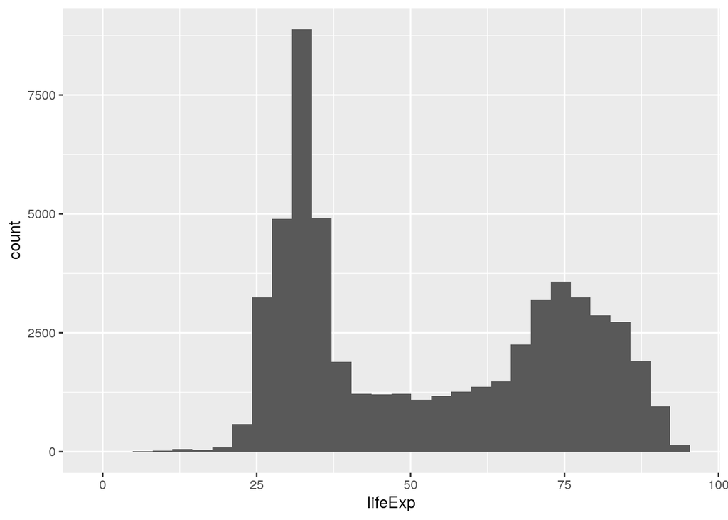

```r
#TODO 8.5: Draw histogram here
library(ggplot2)
ggplot(gapminder2, aes(x = lifeExp)) + geom_histogram()
```

2. Draw side by side boxplots of life expectancy for the years 1900, 1910, 1920, 1930, 1940, 1950, 1960, 1970, 1980, and 1990. You’ll probably want to use `subset` in the `data` specification of `ggplot` to obtain only those 10 specific years. Also, try and use the `seq` function when you subset the data to avoid explicitly creating a vector of these dates.

```r
#TODO 8.6: Draw side boxplots here
typeof(gapminder2$year)
```

```
## [1] "integer"
```

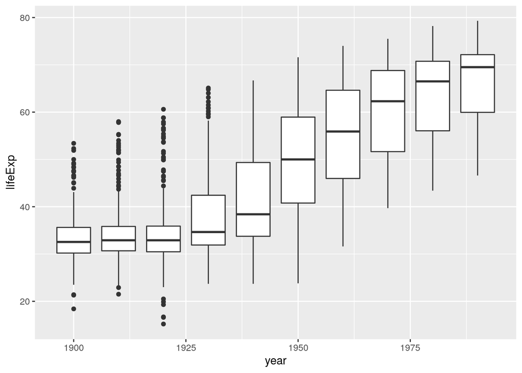

```r
ggplot(gapminder2[gapminder2$year %in% seq(1900, 1990, by=10),], aes(x = year, y = lifeExp)) + geom_boxplot(aes(group = year))
```

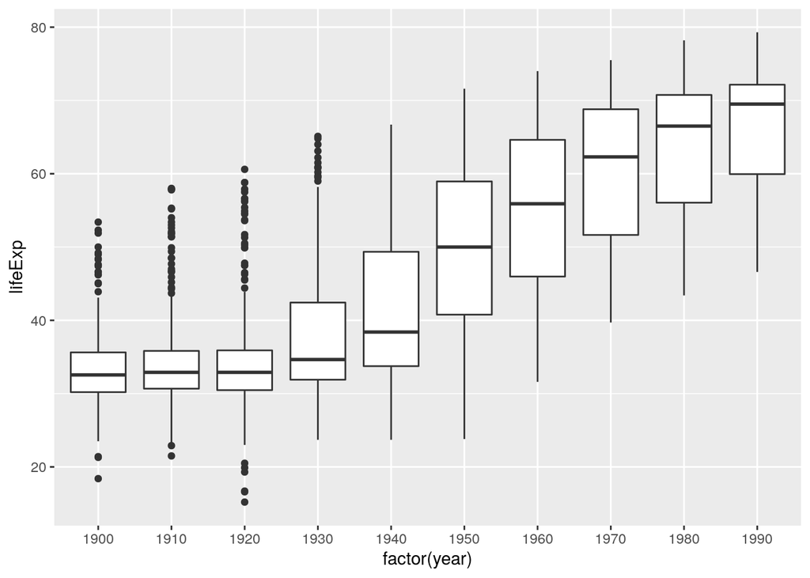

```r
ggplot(gapminder2[gapminder2$year %in% seq(1900, 1990, by=10),], aes(x = factor(year), y = lifeExp)) + geom_boxplot()
```

3. Draw a line graph of the life expectancy against year for the United States.

```r
##TODO 8.7: Draw line graph here
ggplot(gapminder2[gapminder2$country=="United States",]) + geom_line(aes(x = year, y = lifeExp))
```

[output not shown]

```r
#or
ggplot(subset(gapminder2, country == "United States")) + geom_line(aes(x = year, y = lifeExp))
```

[output not shown]

```r
#or
ggplot(data = subset(gapminder2, country == "United States"), aes(x=year, y=lifeExp)) + geom_line()
```

[output not shown]

```r
names(gapminder2)
```

```
## [1] "country" "year"    "lifeExp"
```

4. Draw (on the same set of axes) a line graph of life expectancy for the five most populous countries - China, India, United States, Indonesia, and Brazil - where each country’s line is a different color. (Any idea about why life expectancy dropped so much in many of these countries between 1911-1925?)

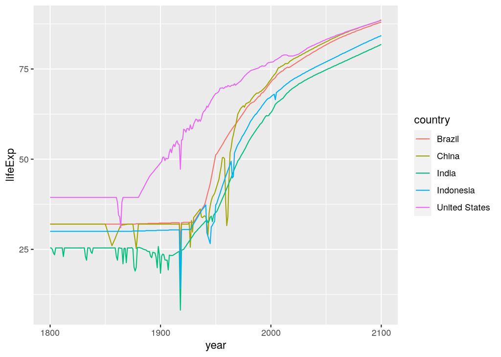

```r
##TODO 8.8: Draw line graph grouped by country here
ggplot(gapminder2[gapminder2$country %in% c("China","India","United States","Indonesia","Brazil"),]) + geom_line(aes(x = year, y = lifeExp, color=country))
```

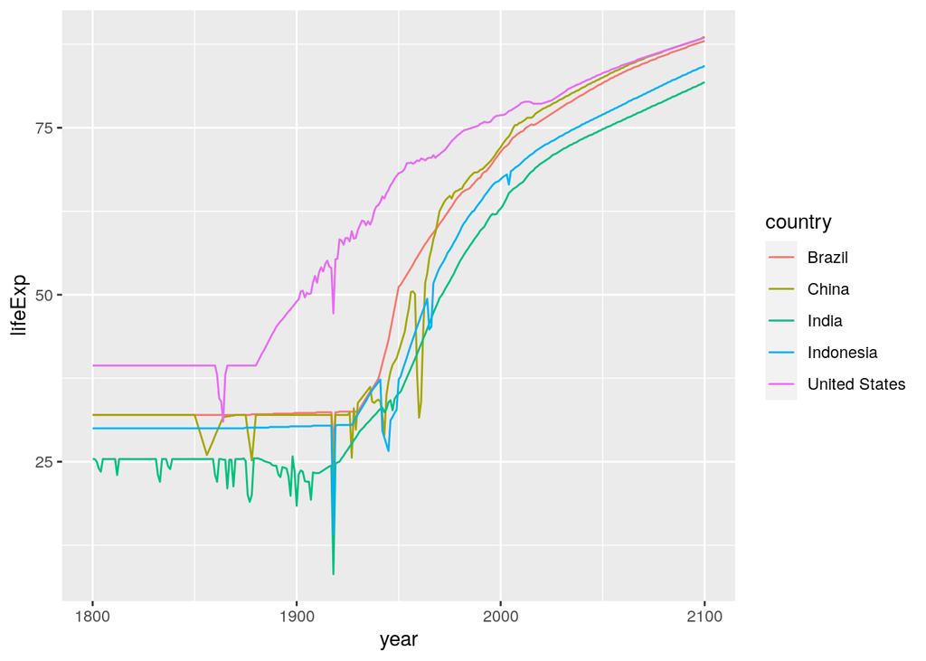

```r
countries <- c("China", "India", "United States", "Indonesia", "Brazil")
lifeExp_countries <- subset(gapminder2, country %in% countries)
ggplot(lifeExp_countries, aes(year, lifeExp, group = country)) + geom_line(aes(color = country))
```

## Challenge Question

This question **will not be graded** and is provided for additional practice building your `R` skills. This is a *challenge* question, and thus not all material has been (or will be) covered.

In this challenge question, we simply provide two additional examples to practice converting data sets between long and wide format. This is an extremely useful data manipulation technique provided by `R` that can greatly save time and reduce any errors if such a task was attempted in Excel. Hopefully after practicing this task a bit more you will become fully convinced to do such data manipulation tasks in `R` rather than in Excel.

Challenge Question 1: The `fish_encounters` data set is currently in long format. The dataset is contained in the `tidyr` package. Use the `help` function to learn about this data set, convert it into wide format, convert it back into long format, and compare your result to the original.

```r
fish.wide <- fish_encounters %>%
  pivot_wider(names_from = station, values_from = seen)
fish.long <- fish.wide %>%
  pivot_longer(cols = -fish, names_to = 'station', values_to = 'seen')
fish.long
```

```
## # A tibble: 209 x 3
##    fish  station  seen
##    <fct> <chr>   <int>
##  1 4842  Release     1
##  2 4842  I80_1       1
##  3 4842  Lisbon      1
##  4 4842  Rstr        1
##  5 4842  Base_TD     1
##  6 4842  BCE         1
##  7 4842  BCW         1
##  8 4842  BCE2        1
##  9 4842  BCW2        1
## 10 4842  MAE         1
## # … with 199 more rows
```

```r
fish_encounters
```

```
## # A tibble: 114 x 3
##    fish  station  seen
##    <fct> <fct>   <int>
##  1 4842  Release     1
##  2 4842  I80_1       1
##  3 4842  Lisbon      1
##  4 4842  Rstr        1
##  5 4842  Base_TD     1
##  6 4842  BCE         1
##  7 4842  BCW         1
##  8 4842  BCE2        1
##  9 4842  BCW2        1
## 10 4842  MAE         1
## # … with 104 more rows
```

Challenge Question 2: The `us_rent_income` data set provides a slightly more complex example. Let’s take a look at the structure of the data set, which again is included in the `tidyr` package.

```r
str(us_rent_income)
```

```
## tibble [104 × 5] (S3: tbl_df/tbl/data.frame)
##  $ GEOID   : chr [1:104] "01" "01" "02" "02" ...
##  $ NAME    : chr [1:104] "Alabama" "Alabama" "Alaska" "Alaska" ...
##  $ variable: chr [1:104] "income" "rent" "income" "rent" ...
##  $ estimate: num [1:104] 24476 747 32940 1200 27517 ...
##  $ moe     : num [1:104] 136 3 508 13 148 4 165 5 109 3 ...
```

```r
head(us_rent_income)
```

```
## # A tibble: 6 x 5
##   GEOID NAME    variable estimate   moe
##   <chr> <chr>   <chr>       <dbl> <dbl>
## 1 01    Alabama income      24476   136
## 2 01    Alabama rent          747     3
## 3 02    Alaska  income      32940   508
## 4 02    Alaska  rent         1200    13
## 5 04    Arizona income      27517   148
## 6 04    Arizona rent          972     4
```

These data are from the 2017 American Community Survey. The `GEOID` and `NAME` columns serve to identify the state the data come from. The `variable` gives the name of the variable that is estimated. The estimate for that value is `estimate` and the margin of error around that estimate is the `moe` column. Here, we have multiple values (i.e., `estimate` and `moe`) that correspond to each state. Convert these data into wide format. Your final data set should have 52 rows and 6 colums, where each row is a state (includes the District of Columbia and Puerto Rico, hence the 52). The names of the columns should be as follows: `GEOID`, `NAME`, `estimate.income`, `estimate.rent`, `moe.income`, `moe.rent`. You will need to use the `names_sep` argument, and supply a vector of columns to the `values_from` argument instead of a single column.

```r
us_rent_income %>%
  pivot_wider(
    names_from = variable,
    names_sep = ".",
    values_from = c(estimate, moe)
  )
```

```
## # A tibble: 52 x 6
##    GEOID NAME                 estimate.income estimate.rent moe.income moe.rent
##    <chr> <chr>                          <dbl>         <dbl>      <dbl>    <dbl>
##  1 01    Alabama                        24476           747        136        3
##  2 02    Alaska                         32940          1200        508       13
##  3 04    Arizona                        27517           972        148        4
##  4 05    Arkansas                       23789           709        165        5
##  5 06    California                     29454          1358        109        3
##  6 08    Colorado                       32401          1125        109        5
##  7 09    Connecticut                    35326          1123        195        5
##  8 10    Delaware                       31560          1076        247       10
##  9 11    District of Columbia           43198          1424        681       17
## 10 12    Florida                        25952          1077         70        3
## # … with 42 more rows
```

Congratulations! You’ve reached the end of Exercise 8.

### Questions?

If you have any lingering questions about the material in this document or in the corresponding chapter, put them here.

*Response…*

### Give us your feedback!

1. How do you feel you’re doing in this class?

*Response…*

2. What could be done to improve your learning experience?

*Response…*